# US Residential Construction Spending

Author

Ankit Mishra

```python
# Load libraries
import pandas as pd
import numpy as np
import matplotlib.pyplot as plt
from statsforecast import StatsForecast
from statsforecast.models import (
    Naive, SeasonalNaive, RandomWalkWithDrift,
    HistoricAverage, WindowAverage
)
from statsmodels.tsa.seasonal import seasonal_decompose, STL

df = pd.read_excel(r"C:\Users\akm10\Time_Series_Data_Analysis\Dataset\construction_spending.xlsx")
```

# Data Description

The data-generating process is driven by several structural and cyclical factors. Key sources of variation include overall economic growth, interest rates and credit availability, government infrastructure spending, housing demand, and seasonality related to weather and construction cycles. Shocks such as recessions, pandemics, or rapid monetary tightening can cause abrupt changes, while long-term trends reflect inflation, population growth, and urban development. Forecasting this variable is moderately difficult: while strong trend and seasonal patterns can be modeled effectively, the series is sensitive to policy changes and economic shocks that are hard to anticipate, which can reduce forecast accuracy during periods of volatility.

# Exploratory Data Analysis

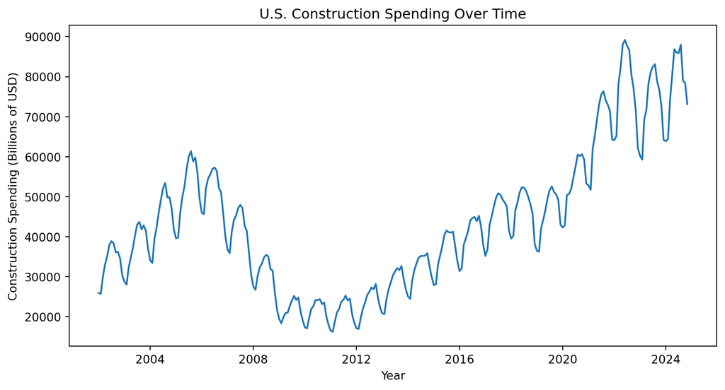

```python
df['date'] = pd.to_datetime(df['date'])

plt.figure(figsize=(10,5))
plt.plot(df['date'], df['construction_spending'])
plt.title("U.S. Construction Spending Over Time")
plt.xlabel("Year")
plt.ylabel("Construction Spending (Billions of USD)")
plt.show()
```

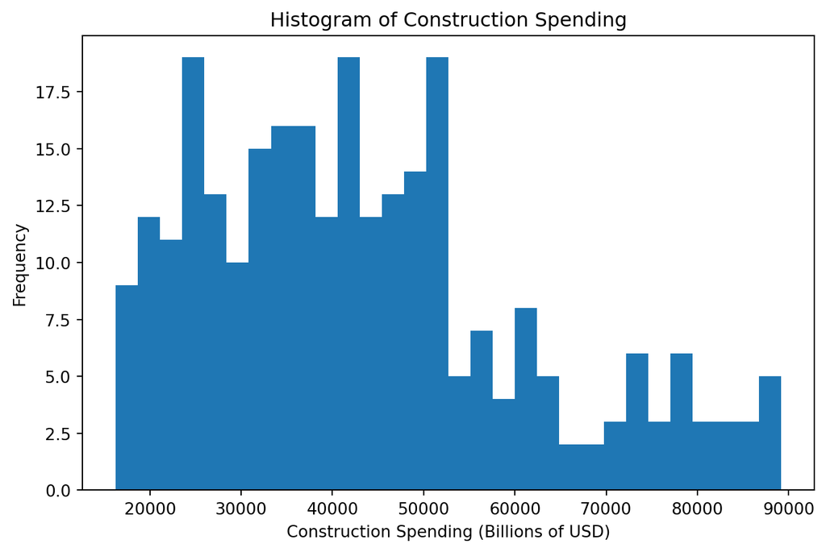

```python
plt.figure(figsize=(8,5))
plt.hist(df['construction_spending'], bins=30)
plt.title("Histogram of Construction Spending")
plt.xlabel("Construction Spending (Billions of USD)")
plt.ylabel("Frequency")
plt.show()
```

The histogram reveals a right-skewed distribution, with more observations concentrated at lower spending levels and a longer tail toward higher values. This skewness reflects the long-term growth of the series rather than random variation around a constant mean.

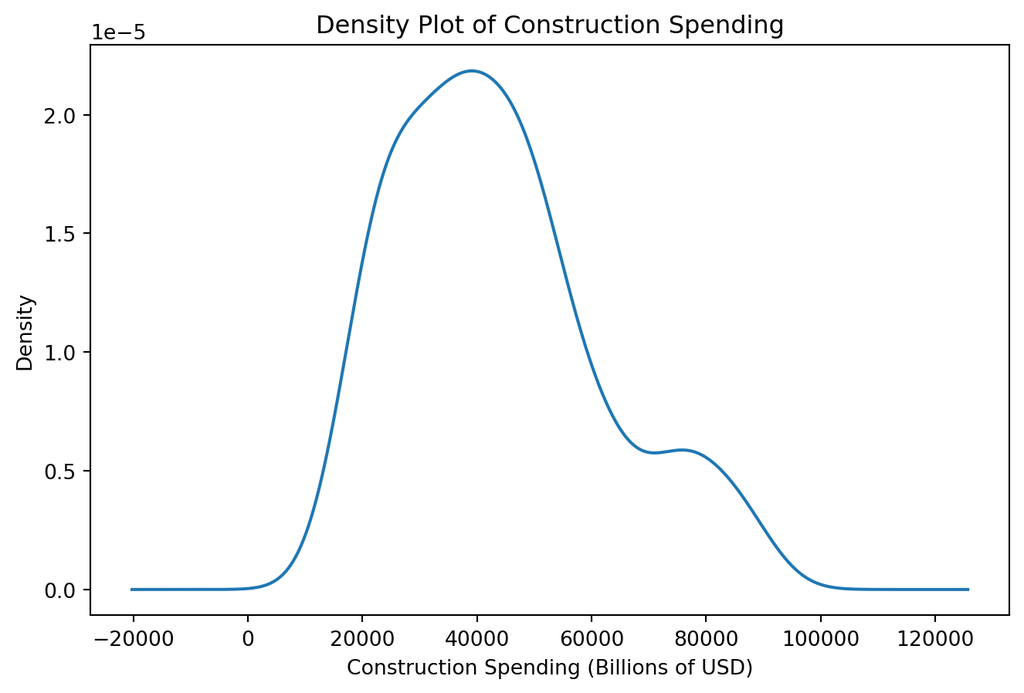

```python
df['construction_spending'].plot(kind='density', figsize=(8,5))
plt.title("Density Plot of Construction Spending")
plt.xlabel("Construction Spending (Billions of USD)")
plt.show()
```

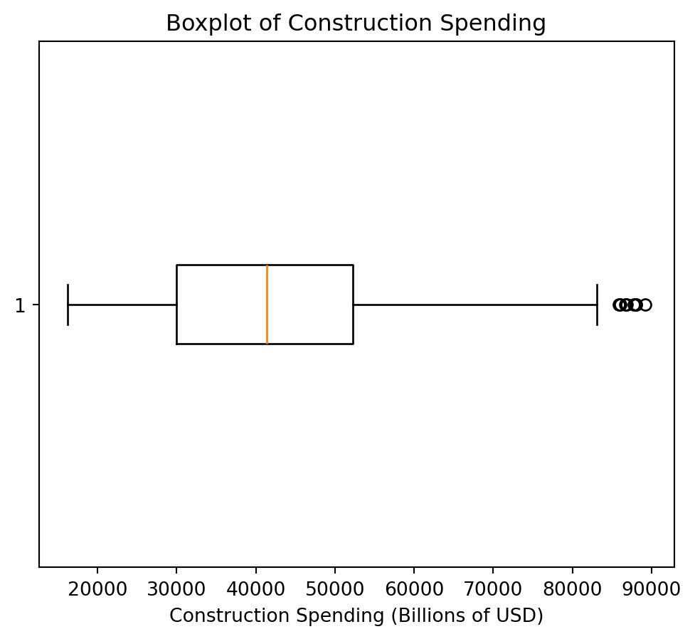

```python
plt.figure(figsize=(6,5))
plt.boxplot(df['construction_spending'], vert=False)
plt.title("Boxplot of Construction Spending")
plt.xlabel("Construction Spending (Billions of USD)")
plt.show()
```

The boxplot highlights several high-value outliers, which correspond to recent years when construction spending reached historically high levels. These are not anomalies in the data but rather reflect structural growth and inflationary effects.

```python
summary_stats = pd.DataFrame({
    "Statistic": [
        "Observations", "Mean", "Median", "Mode",
        "Standard Deviation", "Minimum", "Maximum", "Range"
    ],
    "Value": [
        len(df),
        df['construction_spending'].mean(),
        df['construction_spending'].median(),
        df['construction_spending'].mode()[0],
        df['construction_spending'].std(),
        df['construction_spending'].min(),
        df['construction_spending'].max(),
        df['construction_spending'].max() - df['construction_spending'].min()
    ]
})

summary_stats
```

|  | Statistic | Value |
| --- | --- | --- |
| 0 | Observations | 275.000000 |
| 1 | Mean | 43565.050909 |
| 2 | Median | 41414.000000 |
| 3 | Mode | 16241.000000 |
| 4 | Standard Deviation | 17906.009988 |
| 5 | Minimum | 16241.000000 |
| 6 | Maximum | 89189.000000 |
| 7 | Range | 72948.000000 |

The summary statistics confirm substantial variability in construction spending over time. The large range and standard deviation reflect long-term growth and economic cycles rather than short-term noise. The mean exceeding the median is consistent with the right-skewed distribution observed in the plots.

There are no clear data errors, but the boxplot identifies high-end outliers associated with recent periods of elevated construction activity. These values are economically meaningful and should not be removed. The data exhibit a strong trend, possible seasonality, and sensitivity to macroeconomic shocks such as recessions and policy changes. As a result, while the series contains predictable components, forecasting can be challenging during periods of economic instability.

# Moving Average Visualization

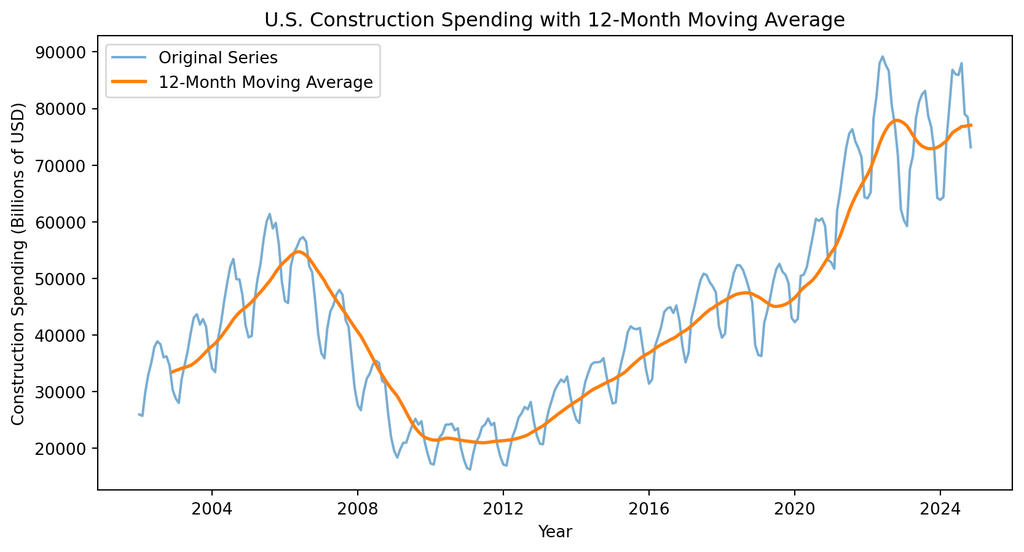

```python
df['MA_12'] = df['construction_spending'].rolling(window=12).mean()

plt.figure(figsize=(10,5))
plt.plot(df['date'], df['construction_spending'], label="Original Series", alpha=0.6)
plt.plot(df['date'], df['MA_12'], label="12-Month Moving Average", linewidth=2)
plt.title("U.S. Construction Spending with 12-Month Moving Average")
plt.xlabel("Year")
plt.ylabel("Construction Spending (Billions of USD)")
plt.legend()
plt.show()
```

The moving average smooths out high-frequency volatility and reveals a clear long-term trend in construction spending. The underlying trajectory shows a decline during the 2008–09 financial crisis, a gradual recovery in the following decade, and a sharp increase after 2020. The moving average confirms that much of the variation in the raw series is driven by persistent structural forces rather than random noise.

# Remainder Series

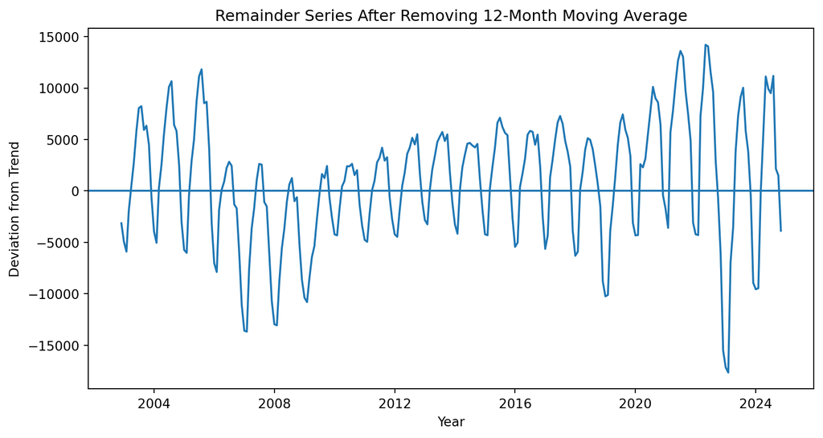

```python
df['REMAINDER'] = df['construction_spending'] - df['MA_12']

plt.figure(figsize=(10,5))
plt.plot(df['date'], df['REMAINDER'])
plt.axhline(0)
plt.title("Remainder Series After Removing 12-Month Moving Average")
plt.xlabel("Year")
plt.ylabel("Deviation from Trend")
plt.show()
```

The remainder series exhibits regular oscillations around zero, indicating the presence of systematic variation not captured by the moving average. These oscillations appear periodic rather than random, suggesting that seasonality remains in the data even after trend smoothing. Occasional larger deviations correspond to economic shocks, but the dominant remaining structure is cyclical.

# Seasonality Assessment via Time Series Decomposition

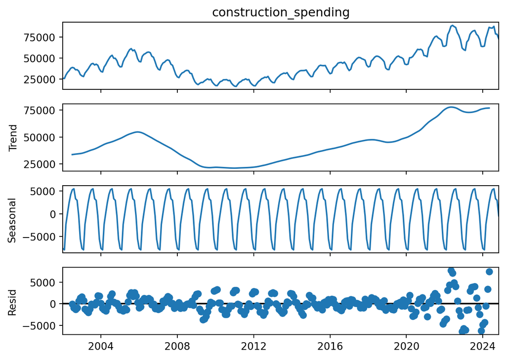

```python
from statsmodels.tsa.seasonal import seasonal_decompose

decomp = seasonal_decompose(df.set_index('date')['construction_spending'], model='additive', period=12)
decomp.plot()
plt.show()
```

The decomposition reveals a strong and persistent seasonal component. The seasonal pattern is stable over time, with recurring peaks and troughs occurring at similar points each year. This aligns well with expectations for construction activity, which is heavily influenced by weather conditions, fiscal-year budgeting, and planning cycles. The trend component mirrors the moving average results, while the remainder captures irregular shocks and short-term volatility.

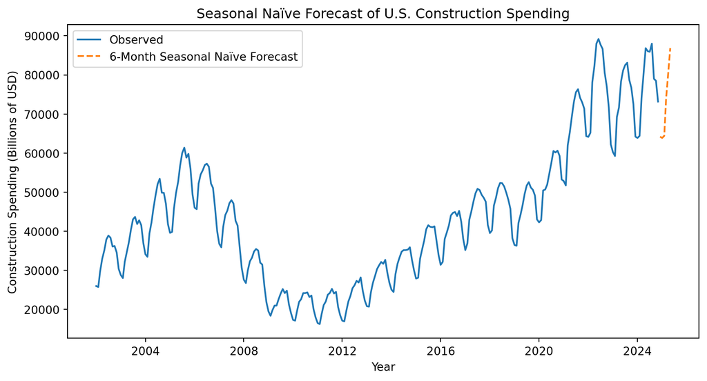

```python
df = df.set_index('date')
# Seasonal naive forecast (period = 12 months)
forecast_horizon = 6
seasonal_lag = 12

forecast_values = df['construction_spending'][-seasonal_lag:-seasonal_lag + forecast_horizon].values
forecast_index = pd.date_range(
    start=df.index[-1] + pd.offsets.MonthBegin(),
    periods=forecast_horizon,
    freq='MS'
)

forecast = pd.Series(forecast_values, index=forecast_index)

# Plot
plt.figure(figsize=(10,5))
plt.plot(df.index, df['construction_spending'], label="Observed")
plt.plot(forecast.index, forecast, label="6-Month Seasonal Naïve Forecast", linestyle="--")
plt.title("Seasonal Naïve Forecast of U.S. Construction Spending")
plt.xlabel("Year")
plt.ylabel("Construction Spending (Billions of USD)")
plt.legend()
plt.show()
```

The seasonal naïve forecast closely mirrors the recurring annual pattern observed in the historical data. By repeating values from the same months in the prior year, the forecast successfully captures the seasonal structure of construction spending. This makes it a more appropriate baseline than a simple naïve forecast, which would fail to account for systematic seasonal fluctuations.

However, the forecast does not capture trend dynamics. Because construction spending has exhibited a strong upward trend in recent years, the seasonal naïve model is likely to underestimate future values during periods of sustained growth. As a result, while the forecast reflects short-term seasonal behavior well, it may lag behind the true level of the series.

# Naïve Forecast with Drift

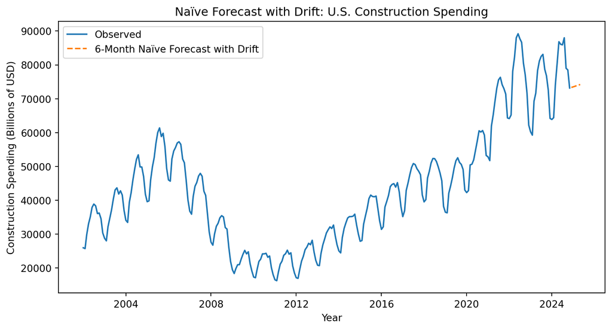

```python
# Forecast horizon
h = 6

# Calculate drift
y = df['construction_spending']
drift = (y.iloc[-1] - y.iloc[0]) / (len(y) - 1)

# Create forecast
forecast_index = pd.date_range(
    start=df.index[-1] + pd.offsets.MonthBegin(),
    periods=h,
    freq='MS'
)

drift_forecast = pd.Series(
    [y.iloc[-1] + drift * i for i in range(1, h + 1)],
    index=forecast_index
)

# Plot
plt.figure(figsize=(10,5))
plt.plot(df.index, df['construction_spending'], label="Observed")
plt.plot(drift_forecast.index, drift_forecast,
         linestyle="--", label="6-Month Naïve Forecast with Drift")
plt.title("Naïve Forecast with Drift: U.S. Construction Spending")
plt.xlabel("Year")
plt.ylabel("Construction Spending (Billions of USD)")
plt.legend()
plt.show()
```

# Conclusion

Baseline forecasting approaches were evaluated using seasonal naïve and naïve-with-drift models. The seasonal naïve forecast effectively captured recurring intra-year patterns but failed to account for ongoing growth, while the drift-based forecast represented the long-run trend but ignored seasonality. Together, these results highlight the limitations of naïve methods and underscore the importance of models that jointly incorporate trend and seasonality. Overall, the findings suggest that more structured time-series models are necessary to accurately forecast construction spending, particularly during periods of economic change.